# 4. Assign Haplotype Backgrounds

Will Hannon

05 October, 2023

```r
## ==== File paths input data ==== ##

if (exists("snakemake")) {

  # Phased variants with haplotype annotations
  updated.data = snakemake@params[["incsv"]]

  # Annotations for MeV genes
  annotations.filepath = snakemake@params[["annotations"]]

  # Counts of all reads bridging *all* pairs of SNP positions
  bridging.reads.data = snakemake@input[[1]]

} else {

  # Phased variants with haplotype annotations
  updated.data = "../../results/variants/clustered_variants.csv"

  # Annotations for MeV genes
  annotations.filepath = "../../config/annotations.csv"

  # Counts of all reads bridging *all* pairs of SNP positions
  bridging.reads.data = "../../results/bridging/bridging_reads.csv"

}
```

```r
## ==== File paths output data ==== ##

# Path to save the results
if (exists("snakemake")) {

  # G1 and G2 assigned variants
  output.path = snakemake@params[['outcsv']]

  # Path to save figures
  figure.dir = paste0(snakemake@params[['figures']], "/")

} else {

  # G1 and G2 assigned variants
  output.path = "../../results/variants/assigned_variants.csv"

  # Path to save figures
  figure.dir = "../../results/figures/"

}

# Make the figure directory if it doesn't exist
if (!file.exists(figure.dir)) {
  dir.create(figure.dir, recursive = TRUE)
  print("Directory created.")
} else {
  print("Directory already exists.")
}
```

```
## [1] "Directory already exists."
```

## Expected Frequency Approach

This approach relies on the expected frequencies of haplotypes given that they’ve arisen on the background of either `Genome 1` or `Genome 2`. We’ll compute the log likelihood of observing the counts a SNP on a given background (SNP - G1, SNP - G2, WT - G1, WT - G2) given the expected frequencies under the assumption that the SNP is on the background of one genotype or the other. We’ll sum the log likelihood over every tissue sample.

```r
loglik.g1.g2 = function(x11, x10, x01, x00, f_g1, f_g2, f_c, error) {

  # Compute the expected frequencies of each possible haplotype given the SNP is on Genome 1
  f11 = (f_c + error) / (1 + 4*error)
  f10 = max(0 + error, (f_g1 - f_c + error)) / (1 + 4*error)
  f01 = (0 + error) / (1 + 4*error)
  f00 = 1 - f11 - f10 - f01

  # What is the probability of observing x11, x10, x01, x00 under these expected frequencies?
  lik.g1 = -(dmultinom(c(x11, x10, x01, x00), prob = c(f11, f10, f01, f00), log = T))

  # Compute the expected frequencies of each possible haplotype given the SNP is on Genome 1
  f11 = (0 + error)/(1 + 4*error)
  f01 = (f_c + error)/(1 + 4*error)
  f00 = max(0 + error, 1 - f_g1 - f01 + error)/(1 + 4*error)
  f10 = 1 - f11 - f00 - f01

  # What is the probability of observing x11, x10, x01, x00 under these expected frequencies?
  lik.g2 = -(dmultinom(c(x11, x10, x01, x00), prob = c(f11, f10, f01, f00), log = T))

  return(c(lik.g1, lik.g2))

}
```

I called the overlapping reads by position rather than SNP. This means that it’s possible for there to be reads that overlap SNPs in more than one haplotype. There is only one position where this is the case. I’ll mask this position below.

```r
# Cutoff for minimum bridging depth
min.bridging.depth = 10

# Labels for the haplotypes
haplotype.labels = updated.df %>%
  select(POS, Haplotype) %>%
  distinct()

# Mask Duplicate Positions
masked.shared.positions = haplotype.labels %>%
  group_by(POS) %>%
  count() %>%
  filter(n > 1) %>%
  pull(POS)

# Filter the bridging read pairs
labled.bridging.df = bridging.df %>%
  # Mask the shared position
  filter(!snp_1 %in% masked.shared.positions, !snp_2 %in% masked.shared.positions) %>%
  # Add the snp_1 haplotype label
  left_join(., dplyr::rename(haplotype.labels, snp_1 = POS, hap_1 = Haplotype)) %>%
  # Add the snp_2 haplotype label
  left_join(., dplyr::rename(haplotype.labels, snp_2 = POS, hap_2 = Haplotype)) %>%
  # Remove all subclonal SNPs
  filter(hap_1 != "subclonal" & hap_2 != "subclonal") %>%
  # We're only comparing to the two major genotypes
  filter(hap_1 %in% c("genome-1", "genome-2") | hap_2 %in% c("genome-1", "genome-2")) %>%
  # We don't want cases with only genome 1 or genome 2
  filter(!(hap_1 %in% c("genome-1", "genome-2") & hap_2 %in% c("genome-1", "genome-2"))) %>%
  # Filter based one some minimum bridging depth cutoff
  filter((`00` + `01` + `10` + `11`) > min.bridging.depth)

# Get all pairs to test
pairs.to.test = labled.bridging.df %>%
  select(snp_1, snp_2) %>%
  distinct()
```

Below, I’ll test all of the pairs of SNPs where one SNP belongs to a phased cluster/haplotype and the other SNP belongs to either `Genome 1` or `Genome 2`.

```r
background.test.df = data.frame()

# Check the background for all SNPs with reads bridging to Genome 1 or Genome 2
for (i in 1:nrow(pairs.to.test)) {

    # Print out the progress
    if(i %% 100 == 0){
      print(paste("Testing pair", i, "out of", nrow(pairs.to.test), "total pairs..."))
    }

    # Get the SNPs being tested
    snp.1 = pairs.to.test[i,]$snp_1
    snp.2 = pairs.to.test[i,]$snp_2

    # Get some info on the SNPs being compared
    snp.1.info = expanded.df %>%
      filter(POS == snp.1) %>%
      select(SNP, POS, Tissue, Haplotype)
    snp.2.info = expanded.df %>%
      filter(POS == snp.2)  %>%
      select(SNP, POS, Tissue, Haplotype)

    # Get the haplotypes for the SNPs being compared
    snp.1.haplotype = unique(snp.1.info$Haplotype)[1]
    snp.2.haplotype = unique(snp.2.info$Haplotype)[1]

    # Get the haplotype of the cluster SNP
    haplotype = setdiff(c(snp.1.haplotype, snp.2.haplotype), c("genome-1", "genome-2"))

    # Get the read overlaps for these two SNPs
    overlaps = labled.bridging.df %>% filter(snp_1 == snp.1 & snp_2 == snp.2)

    # Test the linkage to genome 1 & 2 for each tissue sample
    tissue.test = data.frame()
    for(tissue in unique(haplotype.mean$Tissue)) {
      # Get the frequency of genome 1 and genome 2 in this tissue
      g1.freq = haplotype.mean %>%
        filter(Haplotype == "genome-1", Tissue == tissue) %>%
        pull(AF)
      g2.freq = haplotype.mean %>%
        filter(Haplotype == "genome-2", Tissue == tissue) %>%
        pull(AF)

      # Normalize the frequencies of genome 1 and genome 2
      total.freq = g1.freq + g2.freq
      g1.freq = g1.freq / total.freq
      g2.freq = g2.freq / total.freq

      # Get the haplotype ("cluster") frequency for the comparison
      cluster.freq = max(0, filter(haplotype.mean, Haplotype == haplotype, Tissue == tissue)$AF)

      # Get the bridging reads for this tissue comparison
      comparison.read.counts = overlaps %>%
        filter(Tissue == tissue)

      # x11 refers to the number of reads overlapping the cluster SNP and the G1 SNP
      x11 = NA
      # x10 is the number of reads overlapping G1 SNP and NOT the cluster SNP
      x10 = NA
      # x01 is the number of reads overlapping the cluster SNP and NOT the G1 SNP
      x01 = NA
      # x00 is the number of reads NOT overlapping the cluster SNP and NOT overlapping the G1 SNP
      x00 = NA

      # There are a total of four possible configurations of the data:
      if(!snp.1.haplotype %in% c("genome-1", "genome-2") & snp.2.haplotype %in% c("genome-1", "genome-2")){
        # 1. snp_1 is the cluster SNP, and snp_2 is G1 linked
        if (snp.2.haplotype == "genome-1") {
            x11 = comparison.read.counts$`11`
            x10 = comparison.read.counts$`01`
            x01 = comparison.read.counts$`10`
            x00 = comparison.read.counts$`00`
          }
        # 2. snp_1 is the cluster SNP, and snp_2 is G2 linked
        if (snp.2.haplotype == "genome-2") {
              x11 = comparison.read.counts$`10`
              x10 = comparison.read.counts$`00`
              x01 = comparison.read.counts$`11`
              x00 = comparison.read.counts$`01`
        }
      }
      if(!snp.2.haplotype %in% c("genome-1", "genome-2") & snp.1.haplotype %in% c("genome-1", "genome-2")) {
        # 3. snp_1 is NOT the cluster SNP, and snp_1 is G1 linked
        if (snp.1.haplotype == "genome-1") {
          x11 = comparison.read.counts$`11`
          x10 = comparison.read.counts$`10`
          x01 = comparison.read.counts$`01`
          x00 = comparison.read.counts$`00`
        }
        # 4. snp_1 is NOT the cluster SNP, and snp_1 is G2 linked
        if (snp.1.haplotype == "genome-2") {
          x11 = comparison.read.counts$`01`
          x10 = comparison.read.counts$`00`
          x01 = comparison.read.counts$`11`
          x00 = comparison.read.counts$`10`
        }
      }

      # Compute the log likelihood for the counts determined above
      if (nrow(comparison.read.counts) == 0) {
        results = c(NA, NA)
      } else {
        results = loglik.g1.g2(x11, x10, x01, x00, g1.freq, g2.freq, cluster.freq/total.freq, error = 0.01)
      }
      # Return the results
      tissue.test = rbind(tissue.test, results)
    }

    # Sum the log likelihoods across all tissues
    AICs = 2 * apply(tissue.test, 2, sum, na.rm = TRUE)
    # Calculate relative likelihood
    AIC.min = min(AICs)
    rel.g1 = exp((AIC.min - AICs[1])/2)
    rel.g2 = exp((AIC.min - AICs[2])/2)
    lik.g1 = rel.g1 / (rel.g1 + rel.g2)
    lik.g2 = rel.g2 / (rel.g1 + rel.g2)
    # Determine the background
    background = c("genome-1", "genome-2", "neither")[
      c(lik.g1 > 0.95, lik.g2 > 0.95,
        lik.g1 < 0.95 & lik.g2 < 0.95)
      ]

    # Write to a row
    row = tibble(snp_1 = snp.1, snp_2 = snp.2, background, haplotype, lik.g1, lik.g2)
    background.test.df = rbind(background.test.df, row)

}
```

```
## [1] "Testing pair 100 out of 466 total pairs..."
## [1] "Testing pair 200 out of 466 total pairs..."
## [1] "Testing pair 300 out of 466 total pairs..."
## [1] "Testing pair 400 out of 466 total pairs..."
```

Now, let’s see how the pairs of SNPs agree for each cluster/haplotype.

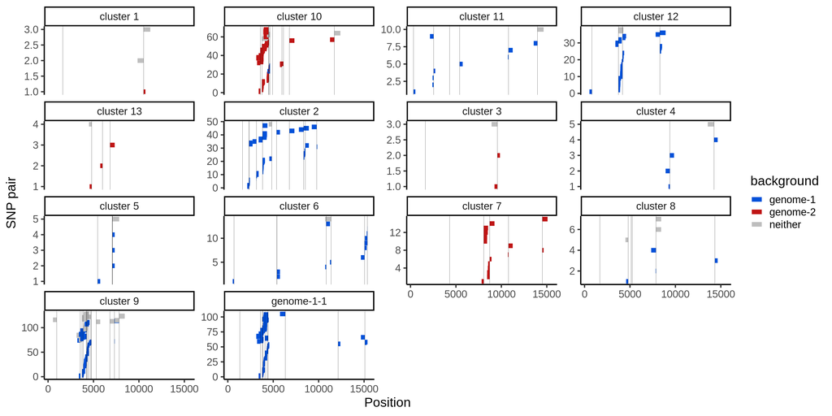

Group by the background assignments for each cluster and count (`Genome 1`, `Genome 2`, and `Neither`). Assign a definitive background based on the max of the two. Pull out the SNPs that disagree for each cluster condition.

```r
background.assignment = background.test.df %>%
  filter(haplotype != "both") %>%
  group_by(haplotype, background) %>%
  count() %>%
  pivot_wider(names_from = background, values_from = n, values_fill = 0) %>%
  select(!neither) %>%
  mutate(Background = case_when(
    `genome-1` > `genome-2` ~ 'genome-1',
    `genome-1` < `genome-2` ~ 'genome-2'
  )) %>%
  mutate(Disagreement = if_else((`genome-1` > 0 & `genome-2` > 0), T, F))
```

There is 1 cluster with SNPs that were assigned to both `Genome 1` and `Genome 2`.

Disagreeing Clusters

| haplotype | genome-2 | genome-1 | Background | Disagreement |
| --- | --- | --- | --- | --- |
| cluster 10 | 60 | 3 | genome-2 | TRUE |

Let’s pull out the SNPs that map to the opposite background as the cluster assignment and see where these SNPs are located in the genome.

```
## [1] 4643
```

There is only 1 SNP that disagrees from the main cluster assignment. Unsurprisingly, this SNP is in the Matrix protein where we expected the highest amount of homoplasy. It’s reasonable that this SNP is present on *both* `Genome 1` and `Genome 2`.

## Annotate the Haplotypes

```r
# Add rows for the non-cluster haplotype options
background.assignment = background.assignment %>%
  ungroup() %>%
  select(Haplotype = haplotype, Background) %>%
  add_row(Haplotype = "genome-1", Background = "genome-1") %>%
  add_row(Haplotype = "genome-2", Background = "genome-2") %>%
  add_row(Haplotype = "both", Background = "both") %>%
  add_row(Haplotype = "subclonal", Background = "subclonal")

# Drop the old background assignments and add the new ones
assigned.df = updated.df %>%
  select(!Background) %>%
  left_join(., background.assignment, by = "Haplotype")
```

Then, to attempt to give some reason to the cluster numbers, I’ll rename them in sequential order starting with the haplotypes assigned to `Genome 1` then moving on the `Genome 2`. Within each background the clusters are ordered based on mean frequency.

```r
# Get the new 'sequential' haplotype names
haplotype.names = assigned.df %>%
  filter(str_detect(Haplotype, "^cluster")) %>%
  select(SNP, AF, Haplotype, Background) %>%
  group_by(Haplotype, Background) %>%
  summarise(AF = mean(AF)) %>%
  group_by(Background) %>%
  arrange(-AF, .by_group=T) %>%
  ungroup() %>%
  mutate(New_Haplotype = paste("cluster", row_number())) %>%
  select(Haplotype, New_Haplotype)
assigned.df = assigned.df %>%
  left_join(., haplotype.names, by = "Haplotype") %>%
  mutate(New_Haplotype = if_else(is.na(New_Haplotype), Haplotype, New_Haplotype)) %>%
  rename(Cluster = Haplotype, Haplotype = New_Haplotype)
```

What do these validated clusters look like?

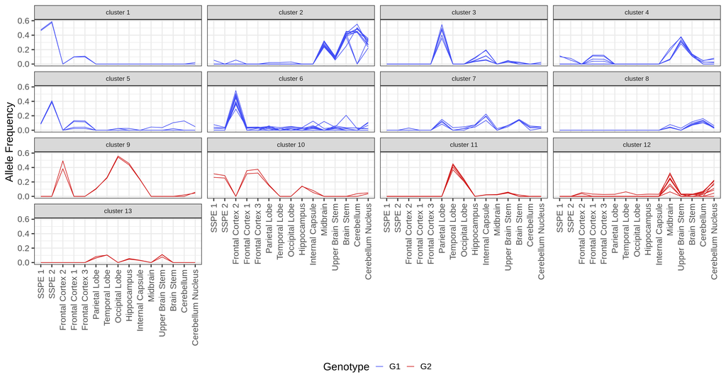

```
## [1] "Writing the results to results/variants/assigned_variants.csv"
```